# INDE546_HW8

Michael Shieh

3/6/2020

# Principle Component Analysis (PCA)

#### The six variable I chose was “Age” (from question 43: How old are you), “CommuteTime” (from question 2: On average, how many minutes does it take you to get to UW from your home), “UberDollar” (from question 12: In the past 7 days, how much did you spend on Uber, Lyft, or other ride-hailing apps in US Dollars), “QualityEd” (from question 37: Please indicate how much you agree or disagree with… I think the UW provides a quality education), “SortWaste” (from question 40: How often do you properly sort waste into trash, recyclables and compost), and Downtown (from question 5: How often do you go to downtown Seattle)

```r
survey <- survey %>%
  rename(Age = How.old.are.you., CommuteTime = On.average..how.many.minutes.does.it.take.you.to.get.to.the.U..Washington.from.your.home.,
         UberDollar = In.the.past.7.days..how.much.did.you.spend.on.Uber.Lyft.or.other.ride.hailing.apps..in.US.dollars..,
         QualityEd = Please.indicate.how.much.you.agree.or.disagree.with.the.following.statements...I.think.the.UW.provides.a.quality.education.,
         SortWaste = How.often.....do.you.properly.sort.waste.into.trash..recyclables.and.compost.,
         Downtown = How.often.do.you...go.to.downtown.Seattle..) %>%
  mutate(UberDollar = replace_na(UberDollar, 0)) %>%
  filter(Age >= 0, CommuteTime >= 0)
```

#### First, I try to see the correlation between each variables. Since the range of each variable varies a lot, I standardize the data first before proceeding.

```r
survey <- survey %>% select(Age, CommuteTime, UberDollar, QualityEd, SortWaste, Downtown)
survey$QualityEd <- as.numeric(survey$QualityEd)
survey$SortWaste <- as.numeric(survey$SortWaste)
survey$Downtown <- as.numeric(survey$Downtown)

survey <- survey %>%
  mutate(Age = (Age - mean(Age))/sd(Age), CommuteTime = (CommuteTime - mean(CommuteTime))/sd(CommuteTime),
         QualityEd = (QualityEd - mean(QualityEd))/sd(QualityEd), SortWaste = (SortWaste - mean(SortWaste))/sd(SortWaste),
         UberDollar = (UberDollar - mean(UberDollar))/sd(UberDollar), Downtown = (Downtown - mean(Downtown))/sd(Downtown))
print(xtable::xtable(cor(survey)), type = "html", html.table.attribute = "border = 2")
```

|  | Age | CommuteTime | UberDollar | QualityEd | SortWaste | Downtown |
| --- | --- | --- | --- | --- | --- | --- |
| Age | 1.00 | 0.35 | -0.02 | 0.07 | -0.11 | -0.17 |
| CommuteTime | 0.35 | 1.00 | -0.09 | -0.07 | -0.09 | -0.16 |
| UberDollar | -0.02 | -0.09 | 1.00 | 0.04 | 0.01 | 0.01 |
| QualityEd | 0.07 | -0.07 | 0.04 | 1.00 | -0.07 | 0.06 |
| SortWaste | -0.11 | -0.09 | 0.01 | -0.07 | 1.00 | 0.06 |
| Downtown | -0.17 | -0.16 | 0.01 | 0.06 | 0.06 | 1.00 |

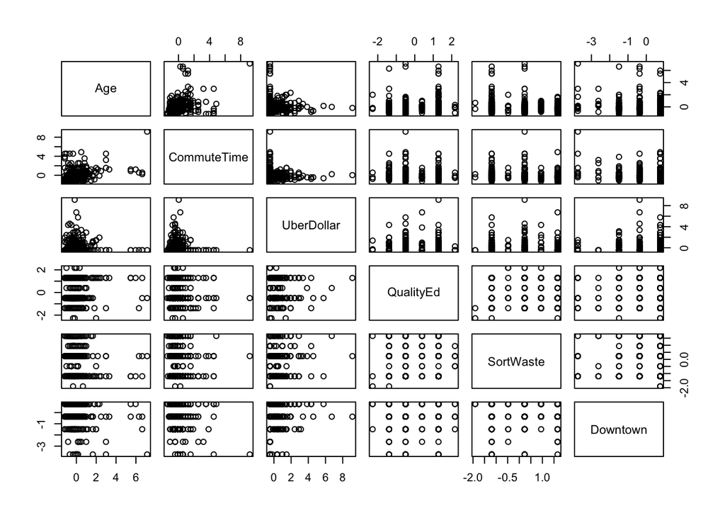

```r
plot(survey)
```

```r
survey_pca <-prcomp(survey, scale = TRUE)
print(survey_pca$sdev)
```

[1] 1.2339704 1.0465939 0.9968165 0.9578558 0.9228632 0.7868615

```r
print(xtable::xtable(survey_pca$rotation), type = "html", html.table.attribute = "border = 2")
```

|  | PC1 | PC2 | PC3 | PC4 | PC5 | PC6 |
| --- | --- | --- | --- | --- | --- | --- |
| Age | 0.60 | -0.16 | -0.06 | 0.34 | 0.15 | -0.69 |
| CommuteTime | 0.60 | 0.14 | 0.03 | 0.21 | 0.34 | 0.67 |
| UberDollar | -0.13 | -0.37 | -0.86 | -0.03 | 0.30 | 0.10 |
| QualityEd | -0.02 | -0.77 | 0.21 | 0.38 | -0.38 | 0.25 |
| SortWaste | -0.28 | 0.44 | -0.24 | 0.79 | -0.21 | 0.02 |
| Downtown | -0.42 | -0.16 | 0.38 | 0.26 | 0.76 | -0.08 |

```r
print(xtable::xtable(summary(survey_pca)), type = "html", html.table.attribute = "border = 2")
```

|  | PC1 | PC2 | PC3 | PC4 | PC5 | PC6 |
| --- | --- | --- | --- | --- | --- | --- |
| Standard deviation | 1.2340 | 1.0466 | 0.9968 | 0.9579 | 0.9229 | 0.7869 |
| Proportion of Variance | 0.2538 | 0.1826 | 0.1656 | 0.1529 | 0.1419 | 0.1032 |
| Cumulative Proportion | 0.2538 | 0.4363 | 0.6019 | 0.7549 | 0.8968 | 1.0000 |

#### I would choose to keep **the first 5 principle components** because I think that no principle components explains a significant amount of variance. Keeping more of them should be a sensible thing to do considering all of them explained a similar proportion of variance. Keeping the first 5 should explain enough variance. Next, I plot the scree plot to see if my decision would fit the elbow rule.

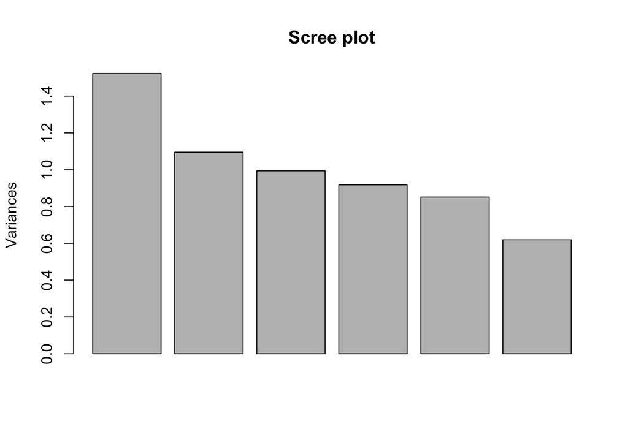

```r
plot(survey_pca, main = "Scree plot")
```

#### From the scree plot there is no clear sign of an elbow existed visually, unless I only keep the first principle components. However, by doing so I could only explain a small amount of variance, which is unacceptable.

# Factor Analysis

#### Setup for Factor Analysis, and initially select to use 2 factors

```r
Age <- cor(survey)[1,]
CommuteTime <- cor(survey)[2,]
UberDollar <- cor(survey)[3,]
QualityEd <- cor(survey)[4,]
SortWaste <- cor(survey)[5,]
Downtown <- cor(survey)[6,]
A_f <- rbind(Age, CommuteTime, UberDollar, QualityEd, SortWaste, Downtown)
```

```r
factanal(covmat = A_f, factors = 2, rotation = "none")
```

```
##
## Call:
## factanal(factors = 2, covmat = A_f, rotation = "none")
##
## Uniquenesses:
##         Age CommuteTime  UberDollar   QualityEd   SortWaste    Downtown
##       0.624       0.652       0.992       0.204       0.965       0.917
##
## Loadings:
##             Factor1 Factor2
## Age          0.609
## CommuteTime  0.585
## UberDollar
## QualityEd            0.892
## SortWaste   -0.170
## Downtown    -0.281
##
##                Factor1 Factor2
## SS loadings      0.826   0.819
## Proportion Var   0.138   0.137
## Cumulative Var   0.138   0.274
##
## The degrees of freedom for the model is 4 and the fit was 0.0044
```

#### Since the variable “UberDollar” did not correlate with any of the factor, I suspected there should be one more factor, so I re-run the setup with 3 factors.

```r
factanal(covmat = A_f, factors = 3, rotation = "none")
```

```
##
## Call:
## factanal(factors = 3, covmat = A_f, rotation = "none")
##
## Uniquenesses:
##         Age CommuteTime  UberDollar   QualityEd   SortWaste    Downtown
##       0.600       0.663       0.716       0.005       0.967       0.916
##
## Loadings:
##             Factor1 Factor2 Factor3
## Age                  0.622
## CommuteTime          0.576
## UberDollar          -0.110   0.520
## QualityEd    0.997
## SortWaste           -0.168
## Downtown            -0.279
##
##                Factor1 Factor2 Factor3
## SS loadings      1.014   0.836   0.284
## Proportion Var   0.169   0.139   0.047
## Cumulative Var   0.169   0.308   0.356
##
## The degrees of freedom for the model is 0 and the fit was 5e-04
```

#### It seems Factor1 is very highly correlated with Quality of Education, and Factor 3 is correlated with Uber Spendings. Also, Factor 2 is highly correlated with Age and Commute Time.

#### Next, I would use oblique rotation to rotate the data to provide more flexibility. I choose oblique rotation because the data is already uncorrelated, so there’s no need to eliminate collinearity.

```r
fa3 <- factanal(covmat = A_f, factors = 3, rotation = "promax")
fa3
```

```
##
## Call:
## factanal(factors = 3, covmat = A_f, rotation = "promax")
##
## Uniquenesses:
##         Age CommuteTime  UberDollar   QualityEd   SortWaste    Downtown
##       0.600       0.663       0.716       0.005       0.967       0.916
##
## Loadings:
##             Factor1 Factor2 Factor3
## Age                  0.635
## CommuteTime          0.559
## UberDollar                   0.535
## QualityEd    0.998
## SortWaste           -0.169
## Downtown            -0.286
##
##                Factor1 Factor2 Factor3
## SS loadings      1.013   0.827   0.296
## Proportion Var   0.169   0.138   0.049
## Cumulative Var   0.169   0.307   0.356
##
## Factor Correlations:
##         Factor1 Factor2 Factor3
## Factor1  1.0000  0.0176  -0.100
## Factor2  0.0176  1.0000  -0.153
## Factor3 -0.1005 -0.1531   1.000
##
## The degrees of freedom for the model is 0 and the fit was 5e-04
```